# single_platform_wram

Nick Fox

Wednesday, February 25, 2015

First I loaded in the data. The dummy code is:

Treatment: SEA = 1, SAL = 0.  
Sex: Female = 1, Male = 0.

# Distance Travelled by Day

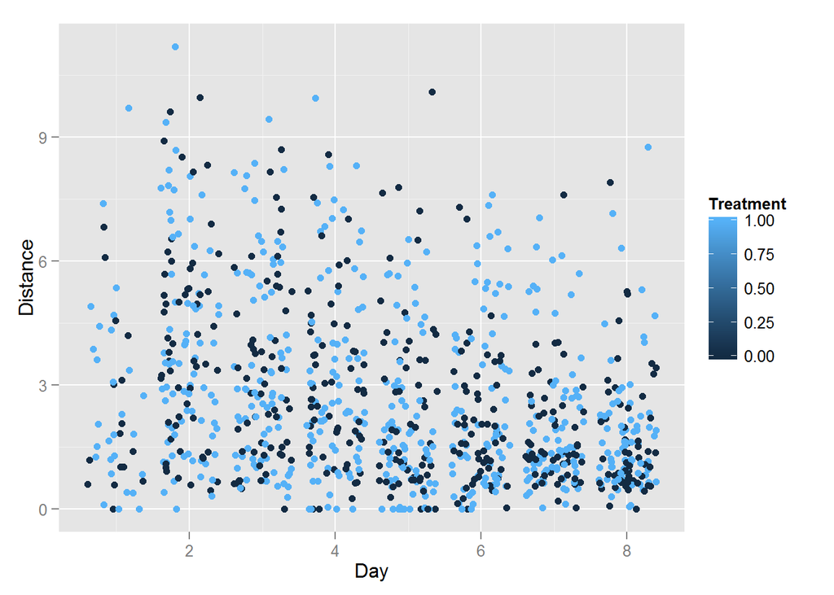

### Then I ran a linear regression on the data and fit the regression line.

```
##
## Call:
## lm(formula = Distance ~ Day + Treatment + Sex + Day:Treatment,
##     data = wram_raw)
##
## Residuals:
##     Min      1Q  Median      3Q     Max
## -3.8163 -1.3919 -0.5479  1.0330  7.6375
##
## Coefficients:
##               Estimate Std. Error t value Pr(>|t|)
## (Intercept)    4.31691    0.25947  16.637  < 2e-16 ***
## Day           -0.33850    0.04794  -7.061 3.16e-12 ***
## Treatment     -0.21913    0.32988  -0.664    0.507
## Sex           -0.16209    0.13751  -1.179    0.239
## Day:Treatment  0.06188    0.06254   0.989    0.323
## ---
## Signif. codes:  0 '***' 0.001 '**' 0.01 '*' 0.05 '.' 0.1 ' ' 1
##
## Residual standard error: 2.037 on 963 degrees of freedom
## Multiple R-squared:  0.09095,    Adjusted R-squared:  0.08717
## F-statistic: 24.09 on 4 and 963 DF,  p-value: < 2.2e-16
```

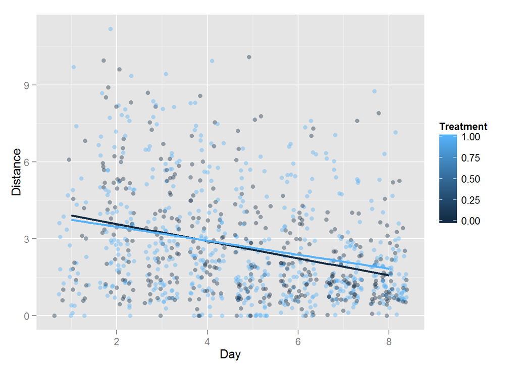

As you can see from the summary of the regression model, there is a **significant main effect of day** on total distance travelled in the wRAM. We did not detect an effect of SEA treatment or Sex.

## —–

Here is the same information using the average of the four trials each day, so each animal has 1 measurement per day.

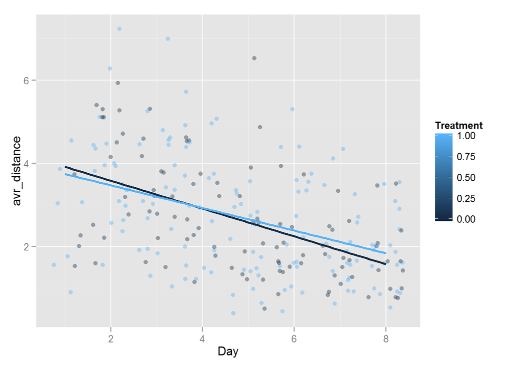

I ran a regresson on this data as well, but the results are exactly the same (as you would expect)

```
##
## Call:
## lm(formula = avr_distance ~ Day + Treatment + Sex + Day:Treatment,
##     data = wram_raw3)
##
## Residuals:
##     Min      1Q  Median      3Q     Max
## -2.7641 -0.8888 -0.1529  0.8070  3.9008
##
## Coefficients:
##               Estimate Std. Error t value Pr(>|t|)
## (Intercept)    4.31691    0.31788  13.580  < 2e-16 ***
## Day           -0.33850    0.05873  -5.764 2.55e-08 ***
## Treatment     -0.21913    0.40415  -0.542    0.588
## Sex           -0.16209    0.16846  -0.962    0.337
## Day:Treatment  0.06188    0.07662   0.808    0.420
## ---
## Signif. codes:  0 '***' 0.001 '**' 0.01 '*' 0.05 '.' 0.1 ' ' 1
##
## Residual standard error: 1.248 on 237 degrees of freedom
## Multiple R-squared:  0.2131, Adjusted R-squared:  0.1998
## F-statistic: 16.05 on 4 and 237 DF,  p-value: 1.214e-11
```

# Latency to Reach Platform (Duration) by Day

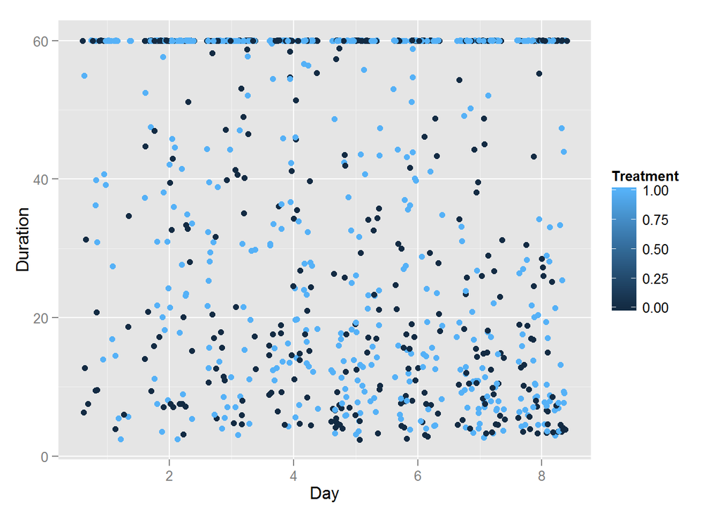

### the linear regression of duration on day and the regression line:

```
##
## Call:
## lm(formula = Duration ~ Day + Treatment + Sex + Day:Treatment,
##     data = wram_raw)
##
## Residuals:
##     Min      1Q  Median      3Q     Max
## -42.703 -21.921   3.051  19.726  36.396
##
## Coefficients:
##               Estimate Std. Error t value Pr(>|t|)
## (Intercept)    48.9429     2.8033  17.459  < 2e-16 ***
## Day            -2.4050     0.5179  -4.644 3.90e-06 ***
## Treatment       4.3630     3.5641   1.224    0.221
## Sex            -6.0984     1.4856  -4.105 4.39e-05 ***
## Day:Treatment  -0.1964     0.6757  -0.291    0.771
## ---
## Signif. codes:  0 '***' 0.001 '**' 0.01 '*' 0.05 '.' 0.1 ' ' 1
##
## Residual standard error: 22.01 on 963 degrees of freedom
## Multiple R-squared:  0.06933,    Adjusted R-squared:  0.06546
## F-statistic: 17.93 on 4 and 963 DF,  p-value: 3.246e-14
```

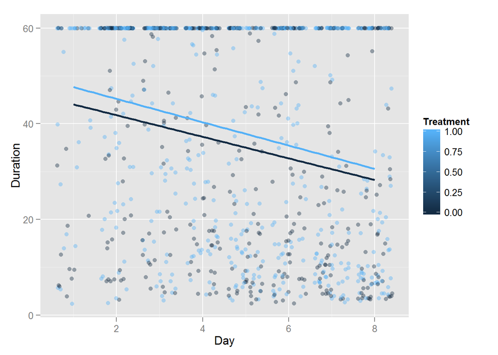

As you can see from the summary of the regression model, there is a **significant main effect of day** and a **significant main effect of sex (females took less time to find the platform)**. We did not detect an effect of treatment.

## —–

Here is the same information using the average of the four trials each day, so each animal has 1 measurement per day.

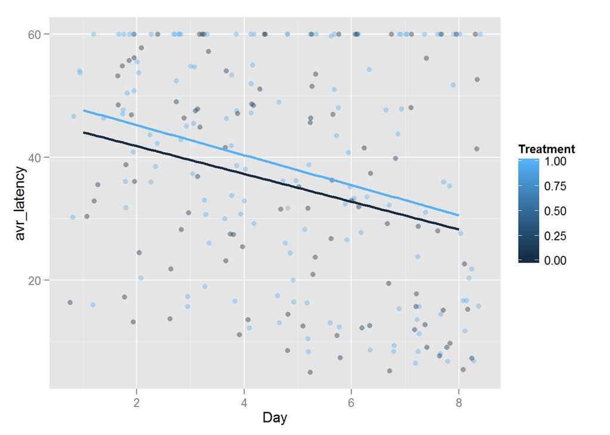

And here is the regression on this averaged latency data:

```
##
## Call:
## lm(formula = avr_latency ~ Day + Treatment + Sex + Day:Treatment,
##     data = wram_raw4)
##
## Residuals:
##     Min      1Q  Median      3Q     Max
## -31.949 -14.249   0.841  14.499  33.604
##
## Coefficients:
##               Estimate Std. Error t value Pr(>|t|)
## (Intercept)    48.9429     4.3563  11.235   <2e-16 ***
## Day            -2.4050     0.8048  -2.988   0.0031 **
## Treatment       4.3630     5.5384   0.788   0.4316
## Sex            -6.0984     2.3086  -2.642   0.0088 **
## Day:Treatment  -0.1964     1.0500  -0.187   0.8518
## ---
## Signif. codes:  0 '***' 0.001 '**' 0.01 '*' 0.05 '.' 0.1 ' ' 1
##
## Residual standard error: 17.1 on 237 degrees of freedom
## Multiple R-squared:  0.1114, Adjusted R-squared:  0.09639
## F-statistic: 7.427 on 4 and 237 DF,  p-value: 1.188e-05
```

The regression output is the same for the averaged data as it is for the whole data.